# A Scrapy TV Show

by: Joshua Roberge

Objective: This Analysis will attempt to understand what it takes to have a successful TV show. To answer the purposed question, this analysis will use three main techniques: one, web scrapping to acquire the data; two, descriptive statistics to understand what factors influence the popularity of movies; and three, Sentiment Analysis to understand peoples emotional connections to the shows they watch.

*Web Sites:*

- https://www.ratingraph.com/top_tv_shows/
- http://besttv.theringer.com/

*Permissions*

- https://www.theringer.com/robots.txt
- Ratinggraph: no user agreement or robot.txt

*Dependencies & lexicons*

- stringr
- rvest
- tidyr
- tidyverse
- RSelenium
- dplyr
- ggplot2
- tidytext
- Leaxicon: AFFIN

*Table of contents*

- Section One Web Scrapping
- Section Two: Descriptive Statistics
- Section Three: Sentiment Analysis

## Section 1: Web Scrapping

### Section One Part One: Best Episodes of All Time Scrapes

This is a ranking of the best tv episodes of all time. The episodes from the website range from 1960 to the years 2019. The reviews from this website will be used to understand the makeup of a good TV show

```r
#### Html getting information ###
best_100<-read_html('http://besttv.theringer.com/')

x=TRUE

rankings<-best_100 %>%
html_nodes('div.meta-bar')%>%
html_node('span.mobile')%>%
html_text()

show<-best_100 %>%
html_nodes('div.meta-bar')%>%
html_node('h4')%>%
html_text()

episode<-best_100 %>%
html_nodes('div.meta-bar')%>%
html_node('h4.ep-number')%>%
html_text()

ep_name<-best_100 %>%
html_nodes('div.show-content-wrapper')%>%
html_node('h2')%>%
html_text()

review<-best_100 %>%
html_nodes('div.blurb')%>%
html_text()


director<-best_100 %>%
html_nodes('div.director')%>%
html_node('span.value')%>%
html_text()

WhereToWatch<-best_100%>%
html_nodes('div.rank')%>%
html_node('div.where-to-watch ul li')%>%
html_text()


writer<-best_100%>%
html_nodes('div.rank')%>%
html_node('div.writer span.value')%>%
html_text()



ranks<-best_100%>%
html_nodes('div.rank')%>%
html_text()


director<-str_replace(str_extract(ranks, "Directed By [:alpha:]+ [:alpha:]+"),"Directed By", "")
Exc_produxer<-str_replace(str_extract(director, "Executive Producer ([:alpha:] ,)+ [:alpha:]"),"Directed By", "")

excutive_producer<-str_extract(ranks, "Executive Producer ([:alpha:]+[:blank:]{1}[:alpha:]+[:blank:]{1})+D")
excutive_producer<-str_replace(str_replace(excutive_producer, " D$", ""), "Executive Producer", "")
director
```

[1] " Michelle MacLaren" " Toby Haynes" " George Plamondon"  
[4] " Philip Martin" " Craig Zisk" " David Solomon"  
[7] " Adam Sandler" " Stephen Hopkins" " Hettie Macdonald"  
[10] " Bruce Gowers" " Barry Sonnenfeld" NA  
[13] " Andrew Barchilon" " Bret Haaland" " Andy Devonshire"  
[16] NA " Bryan Gordon" " Brad Falchuk"  
[19] " Melina Matsoukas" NA " Judd Apatow"  
[22] " Patrick Lope" " Walt Dohrn" " Ryan Murphy"  
[25] " Jody Hill" NA " Beth McCarthy"  
[28] " Jeff Melman" " John Wells" " Greg Yaitanes"  
[31] NA " Bryan Gordon" " David Lynch"  
[34] " Alan Ball" " Louis C" " Brooke Kennedy"  
[37] " Anthony Russo" " Michael Cuesta" " Kevin McCarthy"  
[40] " Dee Rees" " Tony Sacco" " Adam Arkin"  
[43] " Ken Fuchs" " Sam Esmail" " Charles McDougall" [46] NA " JC Gonzalez" " Jack Bender"  
[49] " Pamela Fryman" NA " James Whitmore"  
[52] " Michael Schur" " Lena Dunham" " Jeff Tremaine"  
[55] " Daniel Sackheim" " Craig Zobel" " Juan Jose"  
[58] " Mike Judge" NA " Michael Schur"  
[61] " Steve Shill" " Chuck O" " Ted Kotcheff"  
[64] " Davis Guggenheim" " Ben Bolt" " Trey Parker"  
[67] " Jason Sands" " Don Roy" " Emma Napper"  
[70] " Steven Zaillian" NA " Matt Shakman"  
[73] " Michael Rymer" NA " Nathan Fielder"  
[76] " Joss Whedon" " Gail Mancuso" NA  
[79] " David Mandel" " Kenny Ortega" " Owen Harris"  
[82] " Michael Dinner" " Peter Berg" NA  
[85] " Paul Feig" " Donald Glover" " Brad Kreisberg"  
[88] " Andrew Jarecki" " Thomas Schlamme" " Mark Tinker"  
[91] " Rian Johnson" " Doug Liman" " Steve Buscemi"  
[94] NA " Joe Chappelle" " Neal Brennan"  
[97] " Cary Fukunaga" " David Nutter" " Jennifer Getzinger" [100] " Jack Bender"

```r
### combining Everything ####
Best_eps<-data.frame(WhereToWatch,excutive_producer,ep_name,ranks,show,episode,rankings,director,review)
### saving dirty Version ####
#
# write.csv(Best_eps,'best_eps_dirty.csv')

Best_eps<-read.csv('best_eps_dirty.csv')
```

Messy Data Frame of top rated Episodes

WhereToWatch

excutive_producer

ep_name

ranks

show

episode

rankings

director

Netflix

NA

“Pretty Much Dead Already”

100Character Death Directed By Michelle MacLaren Written By Scott Gimple Watch OnNetflix

100. The Walking Dead

S2 E7

100

Michelle MacLaren

Netflix

NA

“The Reichenbach Fall”

99 Directed By Toby Haynes Written By Steve Thompson Watch OnNetflix

99. Sherlock

S2 E3

99

Toby Haynes

Amazon

Julie Auerbach

“What Happens in Cabo”

98 Executive Producer Julie Auerbach Directed By George Plamondon Watch OnAmazon

98. Laguna Beach

S1 E5

98

George Plamondon

Netflix

NA

“Smoke and Mirrors”

97 Directed By Philip Martin Written By Peter Morgan Watch OnNetflix

97. The Crown

S1 E5

97

Philip Martin

Netflix

NA

“Go”

96Season Finale Directed By Craig Zisk Written By Jenji Kohan, Victoria Morrow, Ron Fitzgerald Watch OnNetflix

96. Weeds

S3 E15

96

Craig Zisk

#### Clean up of Episode Data

```r
Best_eps$WhereToWatch<-str_squish(Best_eps[['WhereToWatch']])
Best_eps<-Best_eps%>%select(-c(ranks))
Best_eps['season']<-as.numeric(str_remove_all(str_extract_all(Best_eps$episode, '^S\\d{1,2}'),'S'))


Best_eps$episode<-as.numeric(str_remove_all(str_extract_all(Best_eps$episode,'E\\d{1,3}'),'E'))

Best_eps$show<-str_remove_all(Best_eps$show,'\\d{1,3}\\. ')
Best_eps$rankings<-as.numeric(str_remove_all(Best_eps$rankings,'\\.'))

write.csv(Best_eps,'best_eps_cleanish.csv')

kable(head(Best_eps[,-which(names(Best_eps)=="review")]), caption = 'Clean Episode Data')%>%kable_styling(bootstrap_options = c("striped", "hover"))
```

Clean Episode Data

| X | WhereToWatch | excutive_producer | ep_name | show | episode | rankings | director | season |
| --- | --- | --- | --- | --- | --- | --- | --- | --- |
| 1 | Netflix | NA | “Pretty Much Dead Already” | The Walking Dead | 7 | 100 | Michelle MacLaren | 2 |
| 2 | Netflix | NA | “The Reichenbach Fall” | Sherlock | 3 | 99 | Toby Haynes | 2 |
| 3 | Amazon | Julie Auerbach | “What Happens in Cabo” | Laguna Beach | 5 | 98 | George Plamondon | 1 |
| 4 | Netflix | NA | “Smoke and Mirrors” | The Crown | 5 | 97 | Philip Martin | 1 |
| 5 | Netflix | NA | “Go” | Weeds | 15 | 96 | Craig Zisk | 3 |
| 6 | Hulu | NA | “Out of Gas” | Firefly | 5 | 95 | David Solomon | 1 |

### Section Two Part One: Best Shows of All Time Scrapes

The website ratinggraph collects information about Tv shows, actors, directors and writers. This data will be used to acquire data for the use of descriptive statistics. These statistics will hopefully be able to answer: ‘Do nominations effect how popular a tv show is?’, ‘Are older TV shows more popular then newer ones?’ and ‘How does genres effect the ratting of a movie?’

#### Code for Web Scrapping Rating Graph

```r
### initiating driver run only once!!!!!!!!!

driver <- rsDriver(browser = c("firefox"))
```

[output not shown]

[output not shown]

[output not shown]

[output not shown]

[output not shown]

[output not shown]

[output not shown]

[output not shown]

[output not shown]

[output not shown]

[output not shown]

[output not shown]

[output not shown]

[output not shown]

[output not shown]

[output not shown]

```r
# Connect to the firefox driver and open it
remote_driver <- driver[["client"]]
remote_driver$open()
```

```r
# # # Point the remote driver to the url of interest

 remote_driver$navigate("https://www.ratingraph.com/top_tv_shows/")
# #
# # ######## getting the list to 250 instead of 25 #######
Sys.sleep(5)
option <- remote_driver$findElement(using = 'xpath', '//*[@id="toplist_length"]/label/select/option[5]')
option$clickElement()
Sys.sleep(5)


# # ### creating a list of string number ie '1','2','3'
tabs<-sprintf("%d",seq(1:60))
# #
# # ### empty data frame for merging ###
master <- data.frame()

for (tab_num in tabs){
# #
# # ##### clicking through the tags #####
option <- remote_driver$findElement(using = 'link text', tab_num)
option$clickElement()

page <-remote_driver$getPageSource()
page1 <-read_html(page[[1]])
table<-page1%>%
html_node('table.display')%>%
html_table()
master<-rbind(master,table)
Sys.sleep(sample(1:5, 1, replace=T))

}

driver$client$close()
# master
# write.csv(master,'master.csv')
master<-read.csv('master.csv')
kable(head(master), caption = 'Dirty Data: Best Movies of all Time')%>%kable_styling(bootstrap_options = c("striped", "hover"))
```

Dirty Data: Best Movies of all Time

X

Rank

Trend

Title

Start.year

End.year

Genres

Language

Runtime..Min..

Seasons

Episodes

Wins

Nominations

Votes..SUM.

Rating..AVG.

1

1

31

Game of Thrones

2011

2019

Action, Adventure, Drama

English

57

8

73

313

505

3,413,751

8.8

2

2

86

Breaking Bad

2008

2013

Crime, Drama, Thriller

English

49

5

62

138

217

1,095,244

9.0

3

3

86

The Walking Dead

2010

Drama, Horror, Thriller

English

44

10

134

69

195

1,202,933

8.1

4

4

100

Supernatural

2005

Drama, Fantasy, Horror

English

44

15

309

22

85

861,000

8.5

5

5

77

Friends

1994

2004

Comedy, Romance

English

22

10

236

71

211

731,459

8.5

6

6

38

Black Mirror

2011

Drama, Sci-fi, Thriller

English

60

5

22

23

75

785,611

7.9

## Cleaing up best shows

```r
## cleaning up master ####
## changing to numeric class
master<-read.csv('master.csv')

master$Rank<-as.numeric(str_replace_all(master$Rank,',',''))

#### trimming white spaces ####
master$Title<-str_trim(master$Title, side='both')



#### cleaning end columns by specific criteria (some 'na are only there bc the show is still in ')
 end_year_piece_one<-as.numeric(str_replace_all(master[1:1500,c('End.year')], '-', '2019'))
 i=1501
 for (endyear in master[c(1501:14780), c('End.year')]){
     if (endyear != '-'){
         end_year_piece_one<-c(end_year_piece_one, endyear)
     }else if (master$Start.year[i]>= 2016){
         end_year_piece_one<-c(end_year_piece_one, 2019)
     }else{
         end_year_piece_one<-c(end_year_piece_one, NA)


}
     i<-i+1

 }

master$End.year<-as.numeric(end_year_piece_one)

##### Numeric fitting  Runtime..####
master$Runtime..Min..<-as.numeric(str_remove_all(master$Runtime..Min.., '-'))


#### master wins #####
master$Wins<-as.numeric(str_replace_all(master$Wins, '-','0'))

master$Nominations<-as.numeric(str_replace_all(master$Nominations, '-','0'))

master$Trend<-as.numeric(master$Trend)
master$Episodes<-as.numeric(master$Episodes)

master$Votes..SUM.<-as.numeric(str_remove_all(str_replace_all(master$Votes..SUM., '-','0'), ','))
write.csv(master,"clean_best_shows_R.csv")
master<-read.csv('clean_best_shows_R.csv')
master<-select(master,-c(X.1,X))
kable(head(master), caption = 'Clean Data: Best Movies of all Time')%>%kable_styling(bootstrap_options = c("striped", "hover"))
```

Clean Data: Best Movies of all Time

| Rank | Trend | Title | Start.year | End.year | Genres | Language | Runtime..Min.. | Seasons | Episodes | Wins | Nominations | Votes..SUM. | Rating..AVG. |
| --- | --- | --- | --- | --- | --- | --- | --- | --- | --- | --- | --- | --- | --- |
| 1 | 24 | Game of Thrones | 2011 | 2019 | Action, Adventure, Drama | English | 57 | 8 | 328 | 313 | 505 | 3413751 | 8.8 |
| 2 | 45 | Breaking Bad | 2008 | 2013 | Crime, Drama, Thriller | English | 49 | 5 | 308 | 138 | 217 | 1095244 | 9.0 |
| 3 | 45 | The Walking Dead | 2010 | 2019 | Drama, Horror, Thriller | English | 44 | 10 | 47 | 69 | 195 | 1202933 | 8.1 |
| 4 | 4 | Supernatural | 2005 | 2019 | Drama, Fantasy, Horror | English | 44 | 15 | 210 | 22 | 85 | 861000 | 8.5 |
| 5 | 43 | Friends | 1994 | 2004 | Comedy, Romance | English | 22 | 10 | 155 | 71 | 211 | 731459 | 8.5 |
| 6 | 30 | Black Mirror | 2011 | 2019 | Drama, Sci-fi, Thriller | English | 60 | 5 | 138 | 23 | 75 | 785611 | 7.9 |

## Section 2: Descriptive Analysis

### Section Two Part One: Nominations Vs. Rating Average

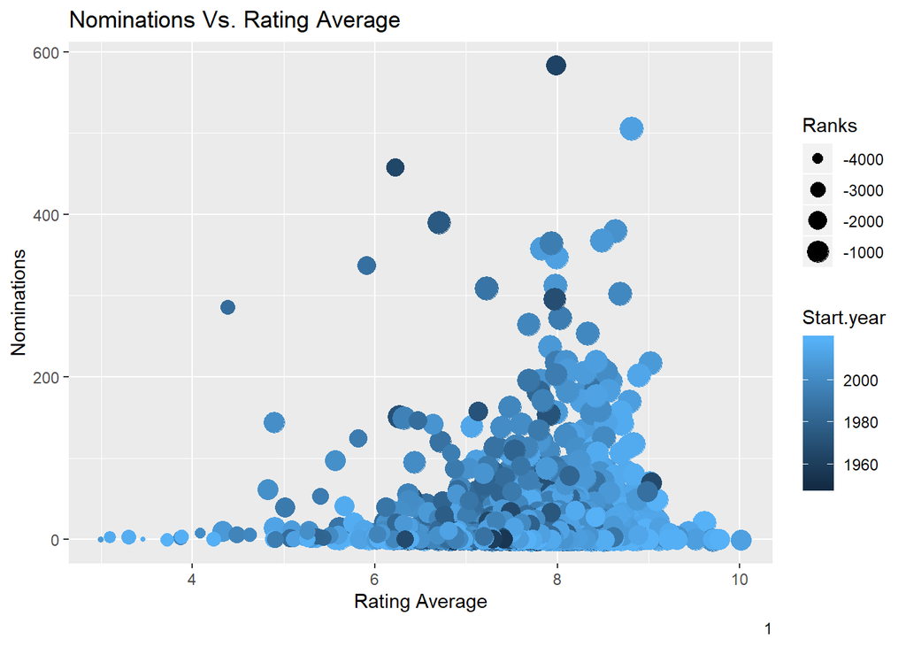

```r
library(ggplot2)
### making a coloumn which calculates how long a tv show has been arround
master$longevity<-master$End.year-master$Start.year

#### Getting Ride of Noisy and less popular movies ####
clean<-master[(master$Rating..AVG.>=0.0 & master$Votes..SUM.>2000 & master$Rank<7000),]
### plotting
plot<-ggplot(clean,aes(y=Nominations, size=-Rank, col=Start.year, x=Rating..AVG.))+geom_point(position='jitter')
plot+labs(size = "Ranks", caption='1')+ggtitle("Nominations Vs. Rating Average")+xlab('Rating Average')
```

Take aways:

- Looking at the graph it appears that New movies are more favorable
- It is hard to say how much of an impact nominations play in Avg Ratting: more analysis is needed

### Section two Part two:How does Genere Effect Movies?

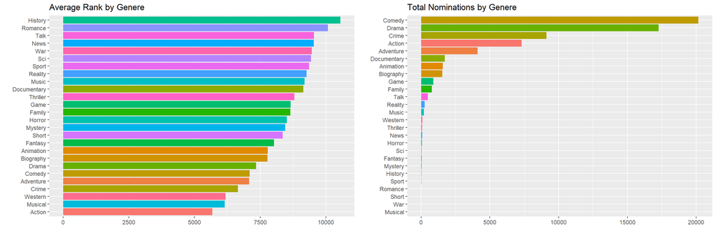

```r
master['Primary_genere']=str_extract(master$Genres,"[:alpha:]+")

#### breaking things down by Genere #####
by_genere<-master%>%
  select(Primary_genere,Rank, Rating..AVG., Votes..SUM., Nominations)%>%
  group_by(Primary_genere)%>%
  summarise(Nominations=sum(Nominations),
            Rank=mean(Rank),
            Rating..AVG.=mean(Rating..AVG.),
            Votes..SUM.=mean(Votes..SUM.),
            Nominations=mean(Nominations))


### plot one: Average Ranks by Genere ####
rank_plt<-ggplot(by_genere, aes(y=Rank, x=reorder(Primary_genere,Rank),fill=Primary_genere))+geom_bar(stat = "identity")+coord_flip()+ theme(legend.position="none")
rank_plt<-rank_plt+xlab('')+ylab('')+ggtitle("Average Rank by Genere")

### plot Two: Total Nominations by Genere###
rank_plt_2<-ggplot(by_genere, aes(y=Nominations, x=reorder(Primary_genere,Nominations),fill=Primary_genere))+geom_bar(stat = "identity")+coord_flip()+ theme(legend.position="none")
rank_plt_2<-rank_plt_2+xlab('')+ylab('')+ggtitle("Total Nominations by Genere")


ggpubr::ggarrange(rank_plt, rank_plt_2, nrow  = 1 )
```

Take Aways:

- Action TV shows seem to do the best when it comes to Average Rank
- History seems to do the worst when it comes to average Rank
- Surprisingly, the comedy generes seems to do the best when it comes to nominations, perhaps this has to do with sitcoms?

### Section Two Part Three: Best Episodes and Where to Find them

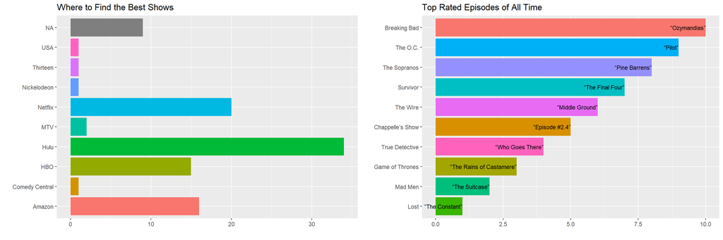

```r
## plot one Where to find the Best episodes ####
WhereToFindPlot<-ggplot(Best_eps,aes(WhereToWatch, fill=WhereToWatch))+geom_bar()+coord_flip()+xlab('')+ylab('')+ggtitle("Where to Find the Best Shows")+theme(legend.position="none")

### Best episodes fo all time ####
top_eps<-ggplot(Best_eps[Best_eps$rankings<=10,], aes(reorder(show, rankings), fill=show,rankings))+geom_bar(stat = 'identity')+coord_flip()+xlab('')+ylab('')+ggtitle("Top Rated Episodes of All Time")+theme(legend.position="none")+geom_text(aes(label=ep_name), size=3, hjust='right')

### putting Everything in one Grid ####
ggpubr::ggarrange(WhereToFindPlot, top_eps, nrow  = 1 )
```

Take Aways:

- Hulu has the most best episodes of all time
- Lost, great tv show, but i am surprissed it had the highest rated episode

## Section 3: Sentiment Analysis

This portion of the analysis will implement sentiment analysis in order to understand what makes a great tv show. There will be three plots to understand these trends: plot one will be a word frequency count plot which will look at the total amount of the most used word in reviews (excluding stop words); plot 2 will be a word cloud plot which will allow us to see the most frequently used words; and plot four will utilize the AFFIN Lexicon in order to understand what emotions are linked to a memorable tv episode.

### Section Three Part One: Most Used Words in best Episode Review

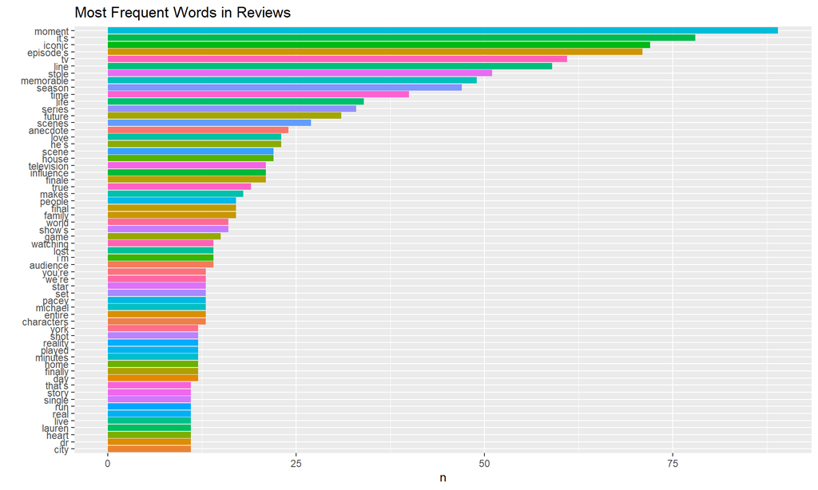

```r
### putting all reviews into one massive string ####
review<-tibble(text=toString(Best_eps$review))


##### making a Data frame with one word per column
tokens<-review%>%
  unnest_tokens(word,text)


### Romoving Stop Words ####
data("stop_words")

tokens<-tokens%>%
  anti_join(stop_words, by='word')

#### word Frequencies and filtering out the top ###
top_word<-tokens%>%
  count(word, sort=TRUE)%>%
  filter(n>10)

### getting ride of the word episode ####
top_word<-top_word[top_word$word!='episode',]

### plotting the most used words ####
ggplot(top_word,aes(reorder(word,n),n, fill=word))+geom_bar(stat = 'identity')+coord_flip()+theme(legend.position="none")+ggtitle('Most Frequent Words in Reviews')+xlab('')
```

take aways:

- Unsurprisingly, more stop words need to be taken out
- The most words used seem to revolve around remembering the how iconic/memorable these tv shows were

### Section Three Part Two:Word Cloud

```r
library(wordcloud2)
top_word<-tokens%>%
  count(word, sort=TRUE)%>%
  filter(n>5)
wordcloud2(top_word, shape =  'star')
```

[interactive chart not shown]

take aways:

- Cool interactive visual
- Most words revolve around the iconic nature of the television show

### Section Three Part Three: Sentiment

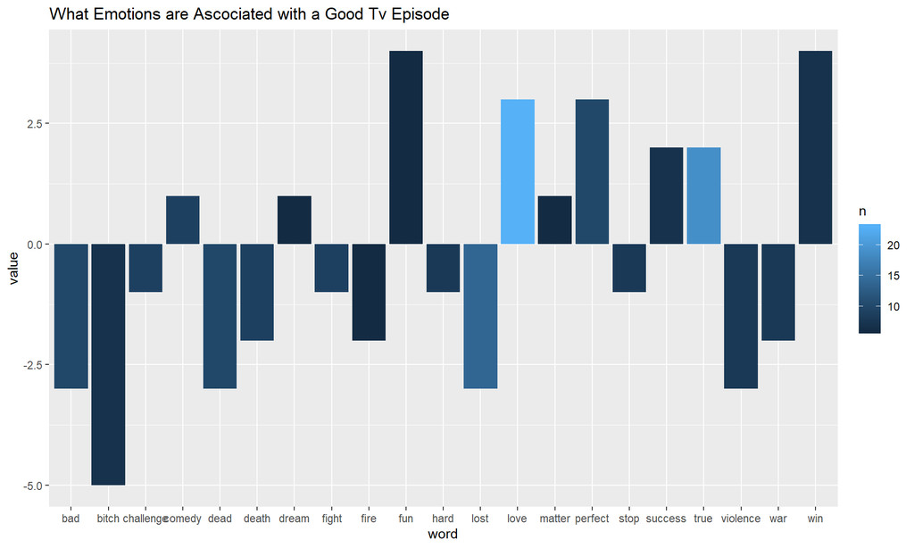

```r
sentiments<-get_sentiments('afinn')

word_sentiments<-top_word%>%
  inner_join(sentiments,by = "word")

ggplot(word_sentiments,aes(word, value, fill=n))+geom_bar(stat='identity')+ggtitle("What Emotions are Ascociated with a Good Tv Episode")
```

take aways:

- Most Reviews correlate with negative emotions when it comes to a good show
- This reveals that people may have an inclination towards the dramatic